# Final Project

Preston Scibek

May 13, 2018

## Intro

url_pitching = https://baseballsavant.mlb.com/statcast_search?hfPT=&hfAB=&hfBBT=&hfPR=&hfZ=&stadium=&hfBBL=&hfNewZones=&hfGT=R%7C&hfC=&hfSea=2018%7C&hfSit=&player_type=pitcher&hfOuts=&opponent=&pitcher_throws=&batter_stands=&hfSA=&game_date_gt=&game_date_lt=&team=BOS&position=&hfRO=&home_road=&hfFlag=&metric_1=&hfInn=&min_pitches=0&min_results=0&group_by=name&sort_col=pitches&player_event_sort=h_launch_speed&sort_order=desc&min_abs=0#results

url_batting = https://baseballsavant.mlb.com/statcast_search?hfPT=&hfAB=&hfBBT=&hfPR=&hfZ=&stadium=&hfBBL=&hfNewZones=&hfGT=R%7C&hfC=&hfSea=2018%7C&hfSit=&player_type=batter&hfOuts=&opponent=&pitcher_throws=&batter_stands=&hfSA=&game_date_gt=&game_date_lt=&team=BOS&position=&hfRO=&home_road=&hfFlag=&metric_1=&hfInn=&min_pitches=0&min_results=0&group_by=name&sort_col=pitches&player_event_sort=h_launch_speed&sort_order=desc&min_abs=0#results

This data comes from the mlb statcast dataset. The data can be found at the above urls by clicking on the icon above the graphs column in the table. Then load the data as shown below.

```r
library(tidyverse)
library(stringr)
library(rvest)
library(ggplot2)
library(plotly)
library(tree)
library(randomForest)


final_pitching_data_table <- read_csv("redsox_pitching_5132018.csv")
final_batting_data_table <- read_csv("redsox_batting_5132018.csv")

head(final_pitching_data_table)
```

```
## # A tibble: 6 x 87
##   pitch_type game_date  release_speed release_pos_x release_pos_z
##   <chr>      <date>     <chr>         <chr>         <chr>
## 1 FF         2018-05-12 96.6          -3.1489       4.8075
## 2 KC         2018-05-12 86.8          -3.0017       4.7448
## 3 FF         2018-05-12 96.3          -3.0122       4.8443
## 4 FF         2018-05-12 96.6          -2.8003       4.8929
## 5 FF         2018-05-12 97.1          -3.0436       4.8279
## 6 KC         2018-05-12 84.3          -2.9241       4.8362
## # ... with 82 more variables: player_name <chr>, batter <int>,
## #   pitcher <int>, events <chr>, description <chr>, spin_dir <chr>,
## #   spin_rate_deprecated <chr>, break_angle_deprecated <chr>,
## #   break_length_deprecated <chr>, zone <chr>, des <chr>, game_type <chr>,
## #   stand <chr>, p_throws <chr>, home_team <chr>, away_team <chr>,
## #   type <chr>, hit_location <chr>, bb_type <chr>, balls <int>,
## #   strikes <int>, game_year <int>, pfx_x <chr>, pfx_z <chr>,
## #   plate_x <chr>, plate_z <chr>, on_3b <chr>, on_2b <chr>, on_1b <chr>,
## #   outs_when_up <int>, inning <int>, inning_topbot <chr>, hc_x <chr>,
## #   hc_y <chr>, tfs_deprecated <chr>, tfs_zulu_deprecated <chr>,
## #   pos2_person_id <chr>, umpire <chr>, sv_id <chr>, vx0 <chr>, vy0 <chr>,
## #   vz0 <chr>, ax <chr>, ay <chr>, az <chr>, sz_top <chr>, sz_bot <chr>,
## #   hit_distance_sc <chr>, launch_speed <chr>, launch_angle <chr>,
## #   effective_speed <chr>, release_spin_rate <chr>,
## #   release_extension <chr>, game_pk <int>, pos1_person_id <chr>,
## #   pos2_person_id_1 <chr>, pos3_person_id <chr>, pos4_person_id <chr>,
## #   pos5_person_id <chr>, pos6_person_id <chr>, pos7_person_id <chr>,
## #   pos8_person_id <chr>, pos9_person_id <chr>, release_pos_y <chr>,
## #   estimated_ba_using_speedangle <chr>,
## #   estimated_woba_using_speedangle <chr>, woba_value <chr>,
## #   woba_denom <chr>, babip_value <chr>, iso_value <chr>,
## #   launch_speed_angle <chr>, at_bat_number <int>, pitch_number <int>,
## #   pitch_name <chr>, home_score <int>, away_score <int>, bat_score <int>,
## #   fld_score <int>, post_away_score <int>, post_home_score <int>,
## #   post_bat_score <int>, post_fld_score <int>
```

```r
head(final_batting_data_table)
```

```
## # A tibble: 6 x 87
##   pitch_type game_date  release_speed release_pos_x release_pos_z
##   <chr>      <date>     <chr>         <chr>         <chr>
## 1 FF         2018-05-12 96.2          -2.1301       5.8072
## 2 FC         2018-05-12 88.8          -2.1697       5.8660
## 3 FC         2018-05-12 88.7          -2.2286       5.8761
## 4 FC         2018-05-12 88.4          -2.3845       5.7680
## 5 FF         2018-05-12 95.4          -2.2892       5.7659
## 6 FF         2018-05-12 94.9          -2.2536       5.8817
## # ... with 82 more variables: player_name <chr>, batter <int>,
## #   pitcher <int>, events <chr>, description <chr>, spin_dir <chr>,
## #   spin_rate_deprecated <chr>, break_angle_deprecated <chr>,
## #   break_length_deprecated <chr>, zone <chr>, des <chr>, game_type <chr>,
## #   stand <chr>, p_throws <chr>, home_team <chr>, away_team <chr>,
## #   type <chr>, hit_location <chr>, bb_type <chr>, balls <int>,
## #   strikes <int>, game_year <int>, pfx_x <chr>, pfx_z <chr>,
## #   plate_x <chr>, plate_z <chr>, on_3b <chr>, on_2b <chr>, on_1b <chr>,
## #   outs_when_up <int>, inning <int>, inning_topbot <chr>, hc_x <chr>,
## #   hc_y <chr>, tfs_deprecated <chr>, tfs_zulu_deprecated <chr>,
## #   pos2_person_id <chr>, umpire <chr>, sv_id <chr>, vx0 <chr>, vy0 <chr>,
## #   vz0 <chr>, ax <chr>, ay <chr>, az <chr>, sz_top <chr>, sz_bot <chr>,
## #   hit_distance_sc <chr>, launch_speed <chr>, launch_angle <chr>,
## #   effective_speed <chr>, release_spin_rate <chr>,
## #   release_extension <chr>, game_pk <int>, pos1_person_id <chr>,
## #   pos2_person_id_1 <chr>, pos3_person_id <chr>, pos4_person_id <chr>,
## #   pos5_person_id <chr>, pos6_person_id <chr>, pos7_person_id <chr>,
## #   pos8_person_id <chr>, pos9_person_id <chr>, release_pos_y <chr>,
## #   estimated_ba_using_speedangle <chr>,
## #   estimated_woba_using_speedangle <chr>, woba_value <chr>,
## #   woba_denom <chr>, babip_value <chr>, iso_value <chr>,
## #   launch_speed_angle <chr>, at_bat_number <int>, pitch_number <int>,
## #   pitch_name <chr>, home_score <int>, away_score <int>, bat_score <int>,
## #   fld_score <int>, post_away_score <int>, post_home_score <int>,
## #   post_bat_score <int>, post_fld_score <int>
```

## Create ID Tables

If we look at the pitching and batting data we will notice that there are fields with ids that are not translated to names. So we will use the batting and pitching data to generate ids for each person. Since the player_name is the name of the batter/pitcher in their respective data sets we should be able to get all the ids by extracting the player_name with the batter field for the batting table and the player_name field with the pitcher field for the pitching data.

```r
batter_id_table <- final_batting_data_table %>%
  group_by(player_name, batter) %>%
  select(player_name, batter) %>%
  distinct

pitcher_id_table <- final_pitching_data_table %>%
  group_by(player_name, pitcher) %>%
  select(player_name, pitcher) %>%
  distinct

head(batter_id_table)
```

```
## # A tibble: 6 x 2
## # Groups:   player_name, batter [6]
##   player_name        batter
##   <chr>               <int>
## 1 Hanley Ramirez     434670
## 2 Andrew Benintendi  643217
## 3 Mookie Betts       605141
## 4 Christian Vazquez  543877
## 5 Jackie Bradley Jr. 598265
## 6 Eduardo Nunez      456488
```

```r
head(pitcher_id_table)
```

```
## # A tibble: 6 x 2
## # Groups:   player_name, pitcher [6]
##   player_name      pitcher
##   <chr>              <int>
## 1 Craig Kimbrel     518886
## 2 Joe Kelly         523260
## 3 Hector Velazquez  584171
## 4 Carson Smith      605476
## 5 David Price       456034
## 6 Brian Johnson     598271
```

## Get Mookie Betts Data

Mookie Betts is having a standout season. I would like to focus on data regarding Mookie’s at bats.

```r
mookie_data <- final_batting_data_table %>%
  filter(player_name=="Mookie Betts")

head(mookie_data)
```

```
## # A tibble: 6 x 87
##   pitch_type game_date  release_speed release_pos_x release_pos_z
##   <chr>      <date>     <chr>         <chr>         <chr>
## 1 FF         2018-05-12 94.9          -2.2536       5.8817
## 2 FF         2018-05-12 95.8          -2.2788       5.8093
## 3 FT         2018-05-12 97.3          -2.4584       5.7709
## 4 FF         2018-05-12 96.1          -2.2799       5.7348
## 5 FF         2018-05-12 95.9          -1.9824       5.7779
## 6 FF         2018-05-12 95.7          -2.3119       5.7480
## # ... with 82 more variables: player_name <chr>, batter <int>,
## #   pitcher <int>, events <chr>, description <chr>, spin_dir <chr>,
## #   spin_rate_deprecated <chr>, break_angle_deprecated <chr>,
## #   break_length_deprecated <chr>, zone <chr>, des <chr>, game_type <chr>,
## #   stand <chr>, p_throws <chr>, home_team <chr>, away_team <chr>,
## #   type <chr>, hit_location <chr>, bb_type <chr>, balls <int>,
## #   strikes <int>, game_year <int>, pfx_x <chr>, pfx_z <chr>,
## #   plate_x <chr>, plate_z <chr>, on_3b <chr>, on_2b <chr>, on_1b <chr>,
## #   outs_when_up <int>, inning <int>, inning_topbot <chr>, hc_x <chr>,
## #   hc_y <chr>, tfs_deprecated <chr>, tfs_zulu_deprecated <chr>,
## #   pos2_person_id <chr>, umpire <chr>, sv_id <chr>, vx0 <chr>, vy0 <chr>,
## #   vz0 <chr>, ax <chr>, ay <chr>, az <chr>, sz_top <chr>, sz_bot <chr>,
## #   hit_distance_sc <chr>, launch_speed <chr>, launch_angle <chr>,
## #   effective_speed <chr>, release_spin_rate <chr>,
## #   release_extension <chr>, game_pk <int>, pos1_person_id <chr>,
## #   pos2_person_id_1 <chr>, pos3_person_id <chr>, pos4_person_id <chr>,
## #   pos5_person_id <chr>, pos6_person_id <chr>, pos7_person_id <chr>,
## #   pos8_person_id <chr>, pos9_person_id <chr>, release_pos_y <chr>,
## #   estimated_ba_using_speedangle <chr>,
## #   estimated_woba_using_speedangle <chr>, woba_value <chr>,
## #   woba_denom <chr>, babip_value <chr>, iso_value <chr>,
## #   launch_speed_angle <chr>, at_bat_number <int>, pitch_number <int>,
## #   pitch_name <chr>, home_score <int>, away_score <int>, bat_score <int>,
## #   fld_score <int>, post_away_score <int>, post_home_score <int>,
## #   post_bat_score <int>, post_fld_score <int>
```

## Events

```r
mookie_data <- mookie_data %>%
  mutate(rbi=post_bat_score-bat_score)

mookie_data %>%
  group_by(events) %>%
  summarize(count=n())
```

```
## # A tibble: 15 x 2
##    events                    count
##    <chr>                     <int>
##  1 double                       15
##  2 field_error                   2
##  3 field_out                    61
##  4 force_out                     3
##  5 grounded_into_double_play     2
##  6 hit_by_pitch                  3
##  7 home_run                     13
##  8 intent_walk                   2
##  9 null                        463
## 10 other_out                     1
## 11 sac_fly                       2
## 12 single                       18
## 13 strikeout                    17
## 14 triple                        1
## 15 walk                         15
```

Lets look at the at bats but grouped based on pitch type.

```r
mookie_data %>%
  group_by(events, pitch_name) %>%
  summarize(count=n())
```

```
## # A tibble: 64 x 3
## # Groups:   events [?]
##    events      pitch_name      count
##    <chr>       <chr>           <int>
##  1 double      2-Seam Fastball     1
##  2 double      4-Seam Fastball     6
##  3 double      Changeup            3
##  4 double      Curveball           1
##  5 double      Slider              4
##  6 field_error Changeup            1
##  7 field_error Slider              1
##  8 field_out   2-Seam Fastball     8
##  9 field_out   4-Seam Fastball    27
## 10 field_out   Changeup           10
## # ... with 54 more rows
```

Some raw data links to column names https://fastballs.wordpress.com/category/pitchfx-glossary/

pfx_x: the horizontal movement, in inches, of the pitch between the release point and home plate, as compared to a theoretical pitch thrown at the same speed with no spin-induced movement. This parameter is measured at y=40 feet regardless of the y0 value.

pfx_z: the vertical movement, in inches, of the pitch between the release point and home plate, as compared to a theoretical pitch thrown at the same speed with no spin-induced movement. This parameter is measured at y=40 feet regardless of the y0 value.

plate_x: the left/right distance, in feet, of the pitch from the middle of the plate as it crossed home plate. The PITCHf/x coordinate system is oriented to the catcher’s/umpire’s perspective, with distances to the right being positive and to the left being negative.

plate_z: the height of the pitch in feet as it crossed the front of home plate.

```r
mookie_bat_data <- mookie_data %>%
  select(events, pitch_name, release_speed, pitcher, bb_type, pfx_x, pfx_z, plate_x, plate_z, launch_angle, launch_speed, hit_distance_sc, sz_top, sz_bot)
mookie_bat_data %>%
  filter(events=="home_run") %>%
  head()
```

```
## # A tibble: 6 x 14
##   events  pitch_name   release_speed pitcher bb_type   pfx_x pfx_z plate_x
##   <chr>   <chr>        <chr>           <int> <chr>     <chr> <chr> <chr>
## 1 home_r~ 2-Seam Fast~ 86.0           112526 fly_ball  -1.2~ 0.76~ -0.2037
## 2 home_r~ 4-Seam Fast~ 92.9           501985 line_dri~ 0.85~ 1.60~ 0.3792
## 3 home_r~ 2-Seam Fast~ 92.9           518633 fly_ball  0.90~ 1.30~ 0.7083
## 4 home_r~ Slider       86.8           518633 fly_ball  -0.2~ 0.13~ -0.0138
## 5 home_r~ Changeup     83.9           518633 fly_ball  1.12~ 1.21~ -0.3759
## 6 home_r~ 4-Seam Fast~ 91.6           592130 fly_ball  -1.1~ 1.32~ 0.6080
## # ... with 6 more variables: plate_z <chr>, launch_angle <chr>,
## #   launch_speed <chr>, hit_distance_sc <chr>, sz_top <chr>, sz_bot <chr>
```

Before we can analyze and graph this we need to clean it up.

```r
mookie_bat_data <- mookie_bat_data %>%
  type_convert(cols(release_speed=col_double(), pfx_x=col_double(), pfx_z=col_double(), plate_x=col_double(), plate_z=col_double(), launch_angle=col_double(), launch_speed=col_double(), hit_distance_sc=col_integer(), sz_top=col_double(), sz_bot=col_double()))

mookie_bat_data$pitch_name <- as.factor(mookie_bat_data$pitch_name)
mookie_bat_data$events <- as.factor(mookie_bat_data$events)
mookie_bat_data$bb_type <- as.factor(mookie_bat_data$bb_type)
head(mookie_bat_data)
```

```
## # A tibble: 6 x 14
##   events pitch_name    release_speed pitcher bb_type   pfx_x pfx_z plate_x
##   <fct>  <fct>                 <dbl>   <int> <fct>     <dbl> <dbl>   <dbl>
## 1 double 4-Seam Fastb~          94.9  572193 line_dr~ -0.546  1.23  -0.684
## 2 null   4-Seam Fastb~          95.8  572193 null     -0.669  1.23   0.837
## 3 null   2-Seam Fastb~          97.3  572193 null     -1.31   1.14   1.24
## 4 null   4-Seam Fastb~          96.1  572193 null     -0.361  1.47  -0.718
## 5 null   4-Seam Fastb~          95.9  572193 null     -0.432  1.52   1.73
## 6 null   4-Seam Fastb~          95.7  572193 null     -0.711  1.30   0.263
## # ... with 6 more variables: plate_z <dbl>, launch_angle <dbl>,
## #   launch_speed <dbl>, hit_distance_sc <int>, sz_top <dbl>, sz_bot <dbl>
```

```r
strike_zone_top <- mean(mookie_bat_data$sz_top, na.rm=TRUE)
strike_zone_bot <- mean(mookie_bat_data$sz_bot, na.rm=TRUE)
strike_zone_front <- 17/2.0/12


graphed <- ggplot() + geom_rect(aes(xmin=-strike_zone_front, xmax=strike_zone_front, ymin=strike_zone_bot, ymax=strike_zone_top), color="black", fill=NA) + geom_point(data=mookie_bat_data, aes(x=plate_x, y=plate_z, text=sprintf("events: %s<br>Pitch Name: %s<br>Release Speed: %s<br>Launch Angle: %s", events, pitch_name, release_speed, launch_angle))) +
  scale_x_continuous(name="Catchers View | left/right distance in feet of center of plate", limits=c(-4, 4), breaks=seq(from=-4, to=4, by=2)) + scale_y_continuous(name="Height above plate In Feet", limits=c(-2, 6), breaks=seq(from=-2, to=6, by=1))

ggplotly(graphed)
```

[interactive chart not shown]

This is rather ugly. Lets do pitches that result in action and color code it by the event that happens.

```r
action <- mookie_bat_data %>%
  filter(events!="null")

graphed <- ggplot() + geom_rect(aes(xmin=-strike_zone_front, xmax=strike_zone_front, ymin=strike_zone_bot, ymax=strike_zone_top), color="black", fill=NA) + geom_point(data=action, aes(x=plate_x, y=plate_z, text=sprintf("events: %s<br>Pitch Name: %s<br>Release Speed: %s<br>Launch Angle: %s", events, pitch_name, release_speed, launch_angle), color=events)) +
  scale_x_continuous(name="Catchers View | left/right distance in feet of center of plate", limits=c(-4, 4), breaks=seq(from=-4, to=4, by=2)) + scale_y_continuous(name="Height above plate In Feet", limits=c(-2, 6), breaks=seq(from=-2, to=6, by=1))

ggplotly(graphed)
```

[interactive chart not shown]

Mookie leads the league in HRS.

```r
action <- mookie_bat_data %>%
  filter(events == "home_run")

graphed <- ggplot() + geom_rect(aes(xmin=-strike_zone_front, xmax=strike_zone_front, ymin=strike_zone_bot, ymax=strike_zone_top), color="black", fill=NA) + geom_point(data=action, aes(x=plate_x, y=plate_z, text=sprintf("events: %s<br>Pitch Name: %s<br>Release Speed: %s<br>Launch Angle: %s", events, pitch_name, release_speed, launch_angle), color=pitch_name)) +
  scale_x_continuous(name="Catchers View | left/right distance in feet of center of plate", limits=c(-4, 4), breaks=seq(from=-4, to=4, by=2)) + scale_y_continuous(name="Height above plate In Feet", limits=c(-2, 6), breaks=seq(from=-2, to=6, by=1))

ggplotly(graphed)
```

[interactive chart not shown]

Lets try to predict the outcome of a pitch.

```r
set.seed(1234)
train_indices <- sample(nrow(mookie_bat_data), nrow(mookie_bat_data)/2)
train_set <- mookie_bat_data[train_indices,]
test_set <- mookie_bat_data[-train_indices,]

mookie_bat_data_converted <- mookie_bat_data %>%
  filter(events!="null") %>%
  filter(events!="intent_walk") %>%
  select(events, pitch_name, release_speed, plate_x, plate_z)



#mookie_bat_data_converted$pitch_name = as.numeric(mookie_bat_data_converted$pitch_name)
#mookie_bat_data_converted$events = as.numeric(mookie_bat_data_converted$events)
mookie_bat_data_converted
```

```
## # A tibble: 153 x 5
##    events      pitch_name      release_speed plate_x plate_z
##    <fct>       <fct>                   <dbl>   <dbl>   <dbl>
##  1 double      4-Seam Fastball          94.9 -0.684     3.03
##  2 single      2-Seam Fastball          92.7 -0.661     2.68
##  3 field_out   Changeup                 74.9 -0.0167    3.39
##  4 double      Changeup                 77.8  0.0608    1.58
##  5 field_out   4-Seam Fastball          89.8  0.404     2.85
##  6 strikeout   Slider                   84.3  1.34      1.21
##  7 field_error Slider                   86.0  0.646     3.05
##  8 field_out   Cutter                   85.5  0.471     2.67
##  9 field_out   2-Seam Fastball          93.8 -0.765     2.74
## 10 strikeout   Curveball                78.8  0.990     1.92
## # ... with 143 more rows
```

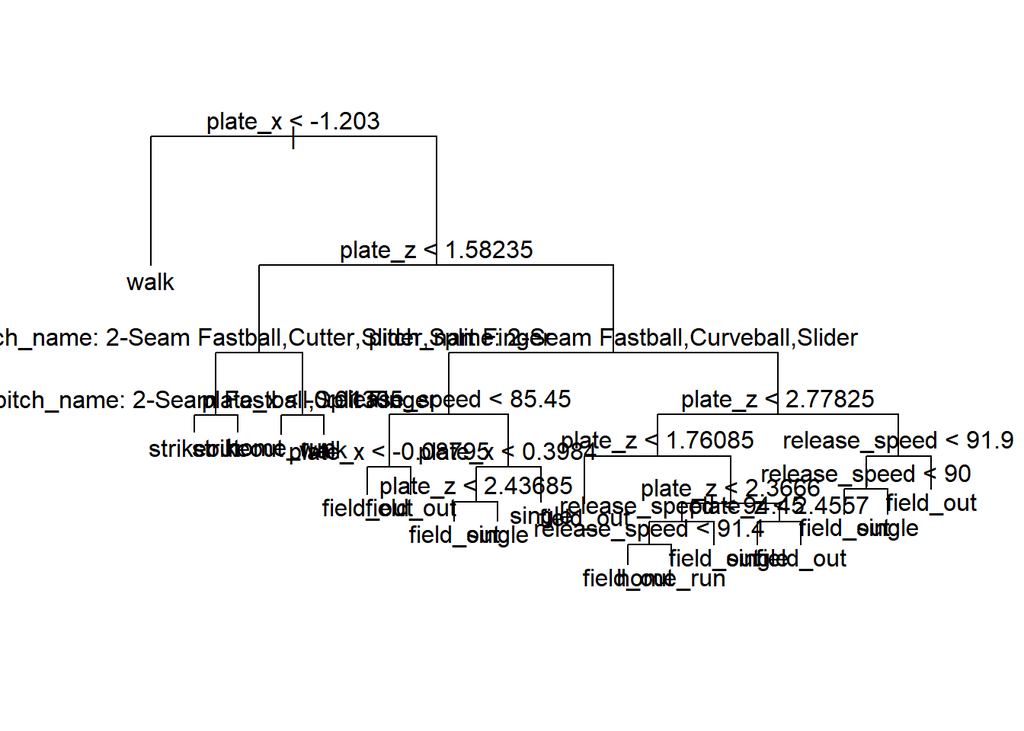

```r
mookie_tree <- tree(events~pitch_name+plate_x+plate_z+release_speed, data=mookie_bat_data_converted)
plot(mookie_tree)
text(mookie_tree, pretty=0)
```

```r
# Random Forest

#mookie_rf <- randomForest(events~pitch_name+plate_x+plate_z, importance=TRUE, mtry=3, data=train_set, na.action=na.roughfix)

#variable_importance <- importance(mookie_rf)
#knitr::kable(head(round(variable_importance, digits=2)))
```